# World Happiness Analysis

**Final Project**

**Authors:** Benjamin Heindl, Victoria Haley, Nadia Paquin

**Course:** IST 652

**Date:** August 31, 2023

## Summary Question

"How do various socio-economic, demographic, and other factors influence a country's happiness ranking, and can specific patterns or insights be derived to better understand the sources of happiness among nations?"

## Description

The analysis is divided into several sections:

1. **Setup and Data Merging:** Setting up the environment and merging the World Happiness Report data with the countries' additional statistics.
2. **Data Preprocessing:** Cleaning and preprocessing the data for analysis, handling missing values, and ensuring consistent data types.
3. **Exploratory Data Analysis:** Providing an overview of the data
4. **Factor Analysis:** Investigating which socio-economic, demographic, and other factors have the strongest relationship with a country's happiness ranking.
5. **Regional Comparisons:** Comparing and contrasting happiness scores and key influencing factors among different world regions.
6. **Predictive Modeling:** Building a regression model to predict happiness scores based on selected factors.
7. **Conclusion and Future Recommendations:** Summarizing findings, discussing implications for policy-makers and leaders, and suggesting areas for future research.

The goal is to dive deep into the factors that contribute to a nation's perceived happiness and understand how different aspects of a country's statistics can influence its happiness ranking.

## Setup and Data Merging

```python
# Basic libraries
import pandas as pd
import numpy as np
import csv
import xlrd
import kaggle

# Data visualization
import matplotlib.pyplot as plt
import seaborn as sns
import folium
import mapclassify

# Geospatial
import geopandas as gpd
import geopy
from geopy.geocoders import Nominatim
from folium.plugins import MarkerCluster
import pycountry_convert
from pycountry_convert import country_alpha2_to_continent_code, country_name_to_country_alpha2

# Statistical Modeling
import statsmodels.api as sm
from statsmodels.stats.outliers_influence import variance_inflation_factor

# Machine Learning
from sklearn.model_selection import train_test_split, cross_val_score
from sklearn.linear_model import LinearRegression
from sklearn.ensemble import RandomForestRegressor
from sklearn.metrics import mean_squared_error
from sklearn.preprocessing import OneHotEncoder

# Data profiling
import ydata_profiling
from pandas_profiling import ProfileReport
```

```python
def load_data():
    # Load WHR 2023 data
    whr_2023 = pd.read_excel("/Users/benjheindl/Desktop/Summer 2023/IST 652 - Scripting for Data Analysis/Final Project/Final Project Data/WHR2023.xls")

    # Download the dataset from Kaggle
    kaggle.api.dataset_download_files('nelgiriyewithana/countries-of-the-world-2023', path='./', unzip=True)
    df_countries = pd.read_csv('world-data-2023.csv')

    return whr_2023, df_countries

# Execute Load Data Function
data_2023, countries = load_data()
```

```python
# Define a function named 'merge_datasets' that takes in two DataFrames: whr_2023 and df_countries
def merge_datasets(whr_2023, df_countries):
    # Use the 'merge' function from the Pandas library to combine the two DataFrames
    # 'left_on' specifies the column from whr_2023 that will be used for merging ('Country name')
    # 'right_on' specifies the column from df_countries that will be used for merging ('Country')
    # 'how' specifies the type of join to be performed, in this case, an 'inner' join
    # An inner join means that only the rows with matching 'Country name' and 'Country' will
    # be kept in the merged DataFrame
    return pd.merge(whr_2023, df_countries, left_on='Country name', right_on='Country', how='inner')
```

## Data Preprocessing

```python
# Define a function named 'handle_missing_agricultural_land' that takes a DataFrame 'df' as an argument.
def handle_missing_agricultural_land(df):

    # Remove the percentage symbol from the 'Agricultural Land( %)' column's values and convert them to floats.
    # Then, divide by 100 to convert the percentage to a decimal format.
    df["Agricultural Land( %)"] = df["Agricultural Land( %)"].str.rstrip('%').astype('float') / 100.0

    # Calculate the median of the 'Agricultural Land( %)' column after conversion.
    median_agri = df["Agricultural Land( %)"].median()

    # Fill in any missing (NaN) values in the 'Agricultural Land( %)' column with the calculated median value.
    df["Agricultural Land( %)"].fillna(median_agri, inplace=True)

    # Return the updated DataFrame.
    return df
```

```python
# Define a function named 'handle_missing_armed_forces' that takes a DataFrame 'df' as its argument.
def handle_missing_armed_forces(df):

    # Remove commas from the 'Armed Forces size' column's values (if any),
    # and then convert the resulting string values to floats.
    df["Armed Forces size"] = df["Armed Forces size"].str.replace(',', '').astype(float)

    # Calculate the median value for the 'Armed Forces size' column after the conversions.
    median_armed_forces = df["Armed Forces size"].median()

    # Replace any missing (NaN) values in the 'Armed Forces size' column
    # with the calculated median value.
    df["Armed Forces size"].fillna(median_armed_forces, inplace=True)

    # Return the updated DataFrame.
    return df
```

```python
# Define a function named 'handle_missing_birth_rate' that takes a DataFrame 'df' as its argument.
def handle_missing_birth_rate(df):

    # Calculate the median value for the 'Birth Rate' column.
    median_birth_rate = df["Birth Rate"].median()

    # Replace any missing (NaN) values in the 'Birth Rate' column with the calculated median value.
    df["Birth Rate"].fillna(median_birth_rate, inplace=True)

    # Return the updated DataFrame.
    return df
```

```python
# Define a function named 'drop_unneeded_columns' that takes a DataFrame 'df' as its argument.
def drop_unneeded_columns(df):

    # Define a list of column names that are to be removed from the DataFrame.
    cols_to_drop = ["Country", "Abbreviation", "Capital/Major City", "Largest city"]

    # Use the 'drop' function to remove these columns.
    # The 'columns' parameter specifies that we are dropping columns (as opposed to rows).
    return df.drop(columns=cols_to_drop)
```

```python
# Define a function named 'handle_missing_currency' that takes a DataFrame 'df' as its argument.
def handle_missing_currency(df):

    # Define a dictionary that maps country names to their respective currency codes.
    currency_mapping = {
        'Netherlands': 'EUR',
        'Panama': 'PAB',
        'Japan': 'JPY',
        'El Salvador': 'USD',
        'Namibia': 'NAD',
        'Cambodia': 'KHR',
        'Liberia': 'LRD',
        'Zimbabwe': 'USD'
    }

    # Use the 'map' function to apply the currency_mapping to the 'Country name' column in df.
    # This will replace the currency codes for the countries defined in currency_mapping.
    # If a country isn't in the mapping, or its value is missing (NaN), it will be filled with the existing value
    # from the 'Currency-Code' column using 'fillna'.
    df['Currency-Code'] = df['Country name'].map(currency_mapping).fillna(df['Currency-Code'])

    # Return the updated DataFrame.
    return df
```

```python
# Define a function named 'handle_missing_minimum_wage' that takes a DataFrame 'df' as its argument.
def handle_missing_minimum_wage(df):

    # Use the 'fillna' function to replace any missing (NaN) values in the 'Minimum wage'
    # column with the string 'Not Available'.
    df["Minimum wage"].fillna('Not Available', inplace=True)

    # Return the updated DataFrame.
    return df
```

```python
# Define a function named 'handle_missing_tax_revenue' that takes a DataFrame 'df' as its argument.
def handle_missing_tax_revenue(df):

    # Remove the '%' sign from the 'Tax revenue (%)' column's values,
    # convert the resulting string values to floats, and divide by 100 to convert to decimal form.
    df["Tax revenue (%)"] = df["Tax revenue (%)"].str.rstrip('%').astype('float') / 100.0

    # Calculate the median value for the cleaned 'Tax revenue (%)' column.
    median_tax_revenue = df["Tax revenue (%)"].median()

    # Replace any missing (NaN) values in the 'Tax revenue (%)' column with the calculated median value.
    df["Tax revenue (%)"].fillna(median_tax_revenue, inplace=True)

    # Return the updated DataFrame.
    return df
```

```python
# Define a function named 'handle_missing_generic_columns' that takes a DataFrame 'df'
# and a list of column names 'cols_to_impute' as its arguments.
def handle_missing_generic_columns(df, cols_to_impute):

    # Define an inner function 'clean_column' that takes a Series (column) as its argument.
    def clean_column(series):

        # Check if the series has an object data type (typically strings).
        if series.dtype == 'object':

            # Remove special characters like '%' and '$', commas, and then strip leading and trailing whitespaces.
            # Finally, convert the series to float data type.
            series = series.str.replace('%', '', regex=False)\
                            .str.replace('$', '', regex=False)\
                            .str.replace(',', '', regex=False)\
                            .str.strip()\
                            .astype(float)

        # Calculate the median value for the series.
        median_value = series.median()

        # Replace any missing (NaN) values in the series with the median value.
        return series.fillna(median_value)

    # Use the 'apply' function to apply the inner function 'clean_column'
    # to each column specified in 'cols_to_impute'.
    df[cols_to_impute] = df[cols_to_impute].apply(clean_column)

    # Return the updated DataFrame.
    return df
```

```python
# Define the main preprocessing function that takes two DataFrames: 'whr_2023' and 'df_countries'.
def preprocess_data(whr_2023, df_countries):

    # Merge the two datasets 'whr_2023' and 'df_countries'.
    df = merge_datasets(whr_2023, df_countries)

    # Handle missing values in the 'Agricultural Land' column.
    df = handle_missing_agricultural_land(df)

    # Handle missing values in the 'Armed Forces size' column.
    df = handle_missing_armed_forces(df)

    # Handle missing values in the 'Birth Rate' column.
    df = handle_missing_birth_rate(df)

    # Drop columns that are not needed for the analysis.
    df = drop_unneeded_columns(df)

    # Handle missing values or update values in the 'Currency-Code' column.
    df = handle_missing_currency(df)

    # Handle missing values in the 'Minimum wage' column.
    df = handle_missing_minimum_wage(df)

    # Handle missing values in the 'Tax revenue (%)' column.
    df = handle_missing_tax_revenue(df)

    # Define a list of other columns that need generic missing value handling.
    cols_to_impute = [
        "Co2-Emissions", "CPI", "CPI Change (%)", "Fertility Rate", "Forested Area (%)",
        "Gasoline Price", "Gross primary education enrollment (%)", "Gross tertiary education enrollment (%)",
        "Infant mortality", "Life expectancy", "Maternal mortality ratio", "Physicians per thousand",
        "Population: Labor force participation (%)", "Total tax rate", "Unemployment rate", "Urban_population"
    ]

    # Apply generic missing value handling for the columns defined in 'cols_to_impute'.
    df = handle_missing_generic_columns(df, cols_to_impute)

    # Return the fully preprocessed DataFrame.
    return df
```

```python
# Execute the main preprocessing function 'preprocess_data' on the raw datasets 'data_2023' and 'countries'.
# Store the result in the variable 'processed_data'.
processed_data = preprocess_data(data_2023, countries)

# Optionally store the preprocessed data in another variable 'merged_df' for further analysis or reporting.
merged_df = processed_data
```

```python
# Create a new DataFrame 'merged_df3' by dropping specific columns from 'merged_df'.
# The columns are dropped along the axis=1, indicating these are columns.
merged_df3 = merged_df.drop([
    'Dystopia + residual', 'Explained by: Perceptions of corruption',
    'Explained by: Generosity', 'Explained by: Freedom to make life choices',
    'Explained by: Healthy life expectancy', 'Explained by: Social support',
    'Explained by: Log GDP per capita', 'Ladder score in Dystopia',
    'upperwhisker', 'lowerwhisker', 'Standard error of ladder score',
    'Currency-Code', 'Official language',
    'Calling Code'
], axis=1)
```

## Exploratory Data Analysis

```python
# Generate descriptive statistics for 'merged_df3'.
# This will provide a summary of the central tendency, dispersion,
# and shape of the distribution for each numerical column.
print(merged_df3.describe())
```

```
       Ladder score  Logged GDP per capita  Social support  \
count    127.000000             127.000000      127.000000
mean       5.548850               9.445561        0.799766
std        1.137498               1.182277        0.129587
min        1.859000               5.526723        0.341341
25%        4.789500               8.593329        0.724070
50%        5.702700               9.567472        0.827064
75%        6.314700              10.440797        0.896128
max        7.804200              11.659949        0.982533

       Healthy life expectancy  Freedom to make life choices  Generosity  \
count               127.000000                    127.000000  127.000000
mean                 64.916418                      0.792029    0.020497
std                   5.643043                      0.109700    0.140551
min                  51.530212                      0.381642   -0.254276
25%                  60.737579                      0.731251   -0.071674
50%                  65.824997                      0.801329    0.001419
75%                  69.249878                      0.877079    0.118170
max                  74.349464                      0.961408    0.531386

       Perceptions of corruption  Agricultural Land( %)  Armed Forces size  \
count                 127.000000             127.000000       1.270000e+02
mean                    0.725523               0.419472       1.861732e+05
std                     0.176256               0.197102       4.171190e+05
min                     0.146112               0.009000       0.000000e+00
25%                     0.664154               0.288000       1.650000e+04
50%                     0.771366               0.420000       4.100000e+04
75%                     0.845844               0.550500       1.790000e+05
max                     0.929089               0.826000       3.031000e+06

       Birth Rate  ...  Life expectancy  Maternal mortality ratio  \
count  127.000000  ...       127.000000                127.000000
mean    19.416693  ...        73.312992                143.685039
std      9.927887  ...         7.401749                223.800921
min      6.400000  ...        54.000000                  2.000000
25%     10.430000  ...        68.500000                  9.500000
50%     17.580000  ...        74.950000                 38.000000
75%     26.740000  ...        78.400000                175.000000
max     46.080000  ...        84.200000               1140.000000

```

[output cut: 16 more lines]

```
50%           0.156000       37.800000           5.190000      8.066048e+06
75%           0.207000       48.800000           8.580000      2.481907e+07
max           0.372000      219.600000          28.180000      8.429340e+08

         Latitude   Longitude
count  127.000000  127.000000
mean    22.057516   19.338014
std     25.457990   57.124815
min    -40.900557 -106.346771
25%      7.706522   -3.592596
50%     23.684994   19.699024
75%     42.512042   45.058675
max     64.963051  174.885971

[8 rows x 29 columns]
```

**Logged GDP per capita:** With a mean of 9.44, this measure shows substantial variability (std = 1.182). Countries range from economically disadvantaged (min 5.53) to affluent (max 11.66).

**Social Support:** Averaging around 0.8, it has a narrow range from 0.34 to 0.98. The lower quartile at 0.724 suggests that at least 75% of countries have relatively good social support.

**Healthy Life Expectancy:** Averaging around 65 years with a standard deviation of approximately 5.6 years. The range is between 51.53 to 74.35, indicating disparities in healthcare. Freedom to Make Life Choices: This metric also seems to be relatively high across countries, with an average around 0.792. It ranges from 0.38 to 0.96, highlighting that there may be countries where freedom is significantly restricted.

**Generosity:** Varies widely from -0.254 to 0.531, with a mean close to zero. This suggests that the dataset includes countries where people, on average, are not generous as well as countries where people are generous.

**Perceptions of Corruption:** Averages at around 0.73, with values ranging from 0.15 to 0.93. High average suggests that corruption is perceived to be relatively high in the countries studied.

**Life Expectancy:** Ranges from 54 to 84.2 years with a mean of about 73.31 years, again indicating substantial global disparities in healthcare.

**Maternal Mortality Ratio:** Highly variable, with a range from 2 to 1140 and a mean of around 143.69, indicating disparities in maternal health services among countries.

**Physicians per Thousand:** With a mean of 1.98, this measure varies from 0.01 to 7.12, suggesting healthcare resource disparities.

**Labor Force Participation:** Averages around 62.2% with a standard deviation of approximately 10.24. The minimum of 39.3% suggests that in some countries, a significant portion of the population is not in the labor force. Tax Revenue (%), Total Tax Rate, and Unemployment Rate: Vary widely among countries, indicating differing economic conditions.

**Urban Population:** Varies greatly from 248,152 to 842,934,000, likely indicating a mix of countries from different sizes and stages of development. Latitude and Longitude: These are geographic coordinates and their interpretation would be context-dependent.

```python
def get_top_n_results(df, n):
    # Get the top n results sorted highest to lowest by Ladder score and Country
    top_n_results = df.sort_values(by=['Ladder score', 'Country name'], ascending=False)[:n]

    # Add a column for the rank
    top_n_results['Rank'] = range(1, n+1)

    # Reset the index and remove the row numbers
    top_n_results = top_n_results.reset_index(drop=True)

    # Format the rank column
    top_n_results['Rank'] = top_n_results['Rank'].astype(str).str.zfill(2)

    # Return the top n results without row numbers as a string
    return top_n_results[['Rank', 'Country name', 'Ladder score']].to_string(index=False)

# Usage
top_15_results_str = get_top_n_results(merged_df3, 15)
print('Top 15 happiest countries in the world')
print(top_15_results_str)
```

```
Top 15 happiest countries in the world
Rank  Country name  Ladder score
  01       Finland        7.8042
  02       Denmark        7.5864
  03       Iceland        7.5296
  04        Israel        7.4729
  05   Netherlands        7.4030
  06        Sweden        7.3952
  07        Norway        7.3155
  08   Switzerland        7.2401
  09    Luxembourg        7.2279
  10   New Zealand        7.1229
  11       Austria        7.0973
  12     Australia        7.0946
  13        Canada        6.9607
  14 United States        6.8937
  15       Germany        6.8918
```

## Regional Comparisons

```python
# Initialize the Nominatim geolocator with a user_agent named "http".
geolocator = Nominatim(user_agent="http")

# Define a function named 'geolocate' that takes a country name as its argument.
def geolocate(country):
    try:
        # Use the geolocator's 'geocode' method to find the latitude and longitude of the country.
        loc = geolocator.geocode(country)

        # Return the latitude and longitude as a tuple.
        return (loc.latitude, loc.longitude)

    except:
        # If the geolocation fails (for example, if the country name is not recognized),
        # return NaN for both latitude and longitude.
        return (np.nan, np.nan)
```

```python
# Check if 'Latitude' and 'Longitude' columns already exist in 'merged_df3'.
# If they don't exist, then populate them.
if 'Latitude' not in merged_df3.columns or 'Longitude' not in merged_df3.columns:

    # Use the 'apply' method on the 'Country name' column of the DataFrame to run the 'geolocate' function.
    # The 'geolocate' function returns a tuple of (Latitude, Longitude).
    # 'zip(*...)' unpacks these tuples into two separate lists, one for latitude and one for longitude.
    # These lists are then added as new columns to the DataFrame.
    merged_df3['Latitude'], merged_df3['Longitude'] = zip(*merged_df3['Country name'].apply(geolocate))
```

```python
# Initialize a Folium Map object with CartoDB Positron tiles.
world_map = folium.Map(tiles="cartodbpositron")

# Create a MarkerCluster object and add it to the Folium Map.
marker_cluster = MarkerCluster().add_to(world_map)

# Define a function to add markers to the map.
def add_marker(row):
    # HTML template for the popup text.
    popup_text = """
                 Country : {}<br>
                 Healthy Life Expectancy : {}<br>
                 """
    # Format the popup text with data from the DataFrame row.
    popup_text = popup_text.format(
        row['Country name'],
        row['Healthy life expectancy']
    )

    # Create a CircleMarker object and add it to the MarkerCluster.
    folium.CircleMarker(
        location=[row['Latitude'], row['Longitude']],  # Marker position
        radius=5,  # Marker size
        popup=popup_text,  # Popup text
        fill=True  # Fill the marker with color
    ).add_to(marker_cluster)

# Apply the add_marker function to each row in the DataFrame.
# axis=1 means the function will be applied to each row.
merged_df3.apply(add_marker, axis=1)

# Display the Folium Map.
display(world_map)
```

Make this Notebook Trusted to load map: File -> Trust Notebook

[interactive chart not shown]

### Color Map by Global Happiness Score

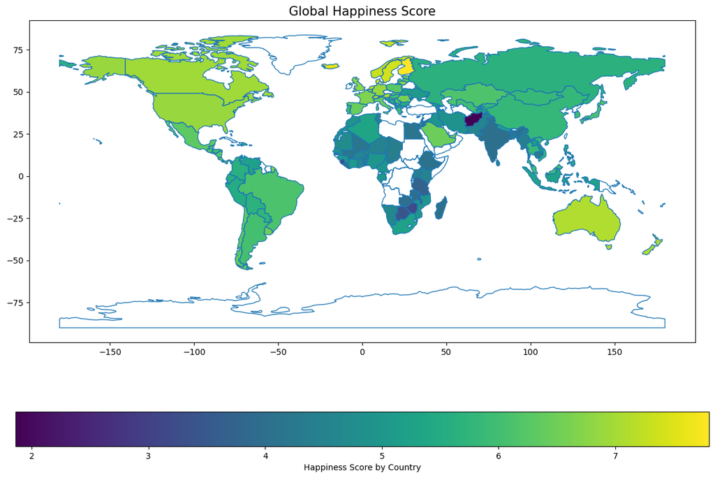

```python
# Function to visualize geographical data based on happiness scores.
def visualize_data(merged_df3):
    # Read a world map from GeoPandas datasets.
    world = gpd.read_file(gpd.datasets.get_path('naturalearth_lowres'))

    # Handle discrepancies in country names between the world dataset and your DataFrame.
    country_name_mapping = {
        'United States': 'United States of America',
        'Dominican Republic': 'Dominican Rep.',
        'Ivory Coast': "Côte d'Ivoire",
        'Bosnia and Herzegovina': 'Bosnia and Herz.'
    }

    # Replace country names in merged_df3 to align with the world dataset.
    merged_df3['Country name'] = merged_df3['Country name'].replace(country_name_mapping)

    # Merge world dataset with your DataFrame on country names.
    world = world.merge(merged_df3, left_on="name", right_on="Country name", how="left")

    # Create a plot using Matplotlib.
    fig, ax = plt.subplots(1, 1, figsize=(15, 10))

    # Plot the boundary lines of countries.
    world.boundary.plot(ax=ax, linewidth=1)

    # Create a choropleth map based on the 'Ladder score' (happiness score).
    world.plot(column='Ladder score', ax=ax, legend=True,
               legend_kwds={'label': "Happiness Score by Country", 'orientation': "horizontal"})

    # Add a title to the plot.
    plt.title('Global Happiness Score', fontsize=15)

    # Show the plot.
    plt.show()

# Execute the visualization function on the processed data.
visualize_data(processed_data)
```

## Factor Analysis

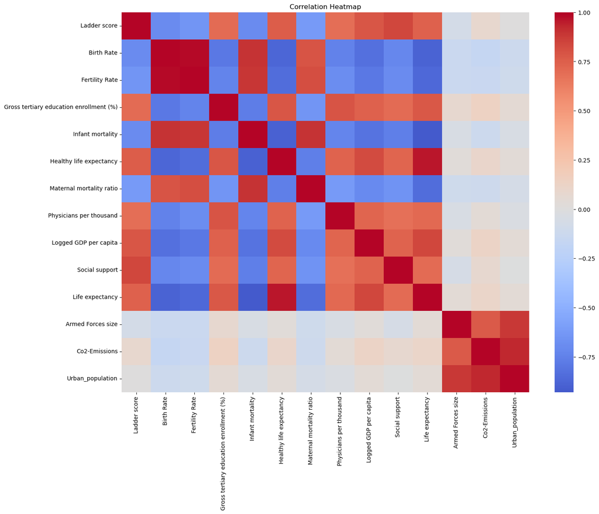

```python
def plot_correlation_heatmap(df, columns):

    # Create a new DataFrame with only the selected columns
    selected_df = df[columns]

    # Generate correlation matrix
    corr_matrix_selected = selected_df.corr(numeric_only=True)

    # Generate the heatmap
    plt.figure(figsize=(16, 12))
    sns.heatmap(corr_matrix_selected, annot=False, cmap='coolwarm', center=0)
    plt.title("Correlation Heatmap")
    plt.show()

# Usage
selected_columns = [
    'Ladder score',
    'Birth Rate',
    'Fertility Rate',
    'Gross tertiary education enrollment (%)',
    'Infant mortality',
    'Healthy life expectancy',
    'Maternal mortality ratio',
    'Physicians per thousand',
    'Minimum wage',
    'Logged GDP per capita',
    'Social support',
    'Life expectancy',
    'Armed Forces size',
    'Co2-Emissions',
    'Population',
    'Urban_population'
]

plot_correlation_heatmap(merged_df3, selected_columns)
```

## Key Observations and Interpretations

### Strong Positive Correlations with Ladder Score:

- **Logged GDP per capita**: 0.788
- **Social support**: 0.841
- **Healthy life expectancy**: 0.762

This means that countries with higher GDP per capita, better social support, and longer healthy life expectancies generally have higher happiness scores.

### Strong Negative Correlations with Ladder Score:

- **Birth Rate**: -0.694
- **Infant mortality**: -0.702
- **Fertility Rate**: -0.649

Countries with higher birth rates, higher infant mortality, and higher fertility rates tend to have lower happiness scores.

### Educational and Health Indicators:

- **Gross tertiary education enrollment (%)**: Positive correlation with Ladder Score (0.702), but strong negative correlation with Birth Rate (-0.789) and Infant mortality (-0.767).

This indicates that countries with better educational opportunities also tend to have lower birth and infant mortality rates, besides higher happiness scores.

### Life and Health Expectancy:

- **Healthy life expectancy and Life expectancy**: Very strongly correlated (0.960).

This suggests that countries with higher life expectancy generally also have higher healthy life expectancy.

### Environmental Factors:

- **CO2 Emissions and Urban Population**: Very strongly correlated (0.927).

This suggests that countries with larger urban populations tend to have higher CO2 emissions.

### Maternal and Infant Health:

- **Maternal mortality ratio and Infant mortality**: Very strongly correlated (0.901).

Countries with higher maternal mortality rates also tend to have higher rates of infant mortality.

### Not So Relevant to Ladder Score:

- **Armed Forces size, CO2-Emissions, and Urban_population** show weak correlations with Ladder score, indicating they might not be significant predictors for happiness in a country.

### Miscellaneous:

- **Physicians per thousand (0.684) and Gross tertiary education enrollment (%) (0.702)** both have relatively strong positive correlations with the Ladder Score.

Countries with more physicians per thousand and higher tertiary education enrollment generally have higher happiness scores.

## Regression Analysis

#### Understand how different variables (independent variables) are affecting the target variable (dependent variable), in this case, the Ladder Score

```python
# Multilinear Regression Model
def run_ols_regression(df, dependent_var, independent_vars):

    X = df[independent_vars]  # Independent Variables
    y = df[dependent_var]  # Dependent Variable

    # Add constant to independent variables
    X = sm.add_constant(X)

    # Fit the model
    model = sm.OLS(y, X).fit()

    # Get the summary
    summary = model.summary()

    return summary

dependent_var = 'Ladder score'
independent_vars = [
    'Logged GDP per capita',
    'Social support',
    'Healthy life expectancy',
    'Freedom to make life choices',
    'Generosity',
    'Perceptions of corruption',
    'Birth Rate',
    'Infant mortality',
    'Fertility Rate'
]

summary = run_ols_regression(merged_df3, dependent_var, independent_vars)
print(summary)
```

```
                            OLS Regression Results
==============================================================================
Dep. Variable:           Ladder score   R-squared:                       0.856
Model:                            OLS   Adj. R-squared:                  0.845
Method:                 Least Squares   F-statistic:                     77.15
Date:                Wed, 06 Sep 2023   Prob (F-statistic):           5.54e-45
Time:                        20:39:28   Log-Likelihood:                -73.093
No. Observations:                 127   AIC:                             166.2
Df Residuals:                     117   BIC:                             194.6
Df Model:                           9
Covariance Type:            nonrobust
================================================================================================
                                   coef    std err          t      P>|t|      [0.025      0.975]
------------------------------------------------------------------------------------------------
const                           -6.0401      1.637     -3.690      0.000      -9.282      -2.798
Logged GDP per capita            0.2261      0.075      3.025      0.003       0.078       0.374
Social support                   4.4630      0.549      8.134      0.000       3.376       5.550
Healthy life expectancy          0.0635      0.019      3.352      0.001       0.026       0.101
Freedom to make life choices     2.2921      0.470      4.875      0.000       1.361       3.223
Generosity                      -0.0681      0.318     -0.214      0.831      -0.697       0.561
Perceptions of corruption       -0.6627      0.285     -2.329      0.022      -1.226      -0.099
Birth Rate                      -0.0357      0.025     -1.407      0.162      -0.086       0.015
Infant mortality                 0.0147      0.006      2.341      0.021       0.002       0.027
Fertility Rate                   0.3292      0.179      1.838      0.069      -0.026       0.684
==============================================================================
Omnibus:                        6.482   Durbin-Watson:                   1.909
Prob(Omnibus):                  0.039   Jarque-Bera (JB):                5.997
Skew:                          -0.488   Prob(JB):                       0.0499
Kurtosis:                       3.423   Cond. No.                     2.95e+03
==============================================================================

Notes:
[1] Standard Errors assume that the covariance matrix of the errors is correctly specified.
[2] The condition number is large, 2.95e+03. This might indicate that there are
strong multicollinearity or other numerical problems.
```

## OLS Regression Analysis Results

### Key Metrics

- **R-squared:** 0.856
- **Adjusted R-squared:** 0.845
- **F-statistic:** 77.15
- **Prob (F-statistic):** 5.54e-45

### Next Steps

1. Remove insignificant variables to improve the model.
2. Check for multicollinearity and possibly remove highly correlated variables.
3. Validate the model using cross-validation techniques.
4. Conduct residual analysis.

```python
import statsmodels.api as sm

def fit_ols_model(df, predictors, target):

    # Defining predictor variables (X) and dependent variable (y)
    X = df[predictors]
    y = df[target]

    # Adding a constant to the predictor variables (it's a best practice!)
    X = sm.add_constant(X)

    # Fitting the OLS model
    model = sm.OLS(y, X).fit()

    # Printing the model summary
    print(model.summary())

    return model

# Usage
predictors = ['Logged GDP per capita', 'Social support', 'Healthy life expectancy',
              'Freedom to make life choices', 'Perceptions of corruption', 'Infant mortality']
target = 'Ladder score'

model = fit_ols_model(merged_df3, predictors, target)
```

```
                            OLS Regression Results
==============================================================================
Dep. Variable:           Ladder score   R-squared:                       0.851
Model:                            OLS   Adj. R-squared:                  0.844
Method:                 Least Squares   F-statistic:                     114.2
Date:                Wed, 06 Sep 2023   Prob (F-statistic):           3.38e-47
Time:                        20:39:28   Log-Likelihood:                -75.171
No. Observations:                 127   AIC:                             164.3
Df Residuals:                     120   BIC:                             184.3
Df Model:                           6
Covariance Type:            nonrobust
================================================================================================
                                   coef    std err          t      P>|t|      [0.025      0.975]
------------------------------------------------------------------------------------------------
const                           -6.2298      1.395     -4.467      0.000      -8.991      -3.468
Logged GDP per capita            0.2406      0.068      3.548      0.001       0.106       0.375
Social support                   4.5244      0.530      8.540      0.000       3.475       5.573
Healthy life expectancy          0.0669      0.018      3.761      0.000       0.032       0.102
Freedom to make life choices     2.1332      0.460      4.634      0.000       1.222       3.045
Perceptions of corruption       -0.7048      0.274     -2.569      0.011      -1.248      -0.162
Infant mortality                 0.0189      0.006      3.438      0.001       0.008       0.030
==============================================================================
Omnibus:                        6.883   Durbin-Watson:                   1.899
Prob(Omnibus):                  0.032   Jarque-Bera (JB):                6.473
Skew:                          -0.528   Prob(JB):                       0.0393
Kurtosis:                       3.330   Cond. No.                     2.41e+03
==============================================================================

Notes:
[1] Standard Errors assume that the covariance matrix of the errors is correctly specified.
[2] The condition number is large, 2.41e+03. This might indicate that there are
strong multicollinearity or other numerical problems.
```

It looks like removing the insignificant predictors improved the model, as indicated by the higher F-statistic and the lower AIC. All the variables now have p-values less than 0.05, suggesting they are significant predictors of "Ladder score."

However, the note about the condition number being large is a red flag for potential multicollinearity. Multicollinearity occurs when predictor variables in a regression model are highly correlated. This can distort the estimates and reduce the statistical power of the analysis.

### Next Steps

1. Check for Multicollinearity: Check the Variance Inflation Factor (VIF) for each predictor variable. A VIF greater than 5-10 suggests high multicollinearity.
2. Re-run the Model: Find the variables with high VIF, consider removing them one by one, and then re-run the regression model, keeping an eye on how the R-squared and other metrics change.
3. Interpret the Model: Once the model is stable (low p-values and acceptable VIF), interpret the coefficients to understand the impact of each predictor on "Ladder score".

```python
def calculate_vif(X):

    # Initialize dataframe to store VIF for each feature
    vif_data = pd.DataFrame()
    vif_data["feature"] = X.columns

    # Calculate and add VIF to dataframe
    vif_data["VIF"] = [variance_inflation_factor(X.values, i) for i in range(len(X.columns))]

    return vif_data

# Usage
predictors = ['Logged GDP per capita', 'Social support', 'Healthy life expectancy',
              'Freedom to make life choices', 'Perceptions of corruption', 'Infant mortality']
X = merged_df3[predictors]
X = sm.add_constant(X)  # Adding constant if needed

vif_data = calculate_vif(X)
print(vif_data)
```

```
                        feature          VIF
0                         const  1220.455623
1         Logged GDP per capita     4.001405
2                Social support     2.933994
3       Healthy life expectancy     6.279781
4  Freedom to make life choices     1.587194
5     Perceptions of corruption     1.455444
6              Infant mortality     6.688666
```

The VIF (Variance Inflation Factor) results indicate potential multicollinearity for the variables "Healthy life expectancy" and "Infant mortality," as their VIF values are greater than 5. This could distort the estimates of these variables and reduce the reliability of the regression model.

### What to Do Next:

1. Remove High VIF Variables: Remove variable with highest VIF ("Infant mortality") and re-run the regression.
2. Re-calculate VIF: After removing "Infant mortality", calculate the VIF values again for the remaining variables to check if multicollinearity is resolved.
3. Re-run the Model: If VIF values come down to acceptable levels, re-run the regression model and interpret the coefficients.

```python
def fit_ols_model(df, predictors, dependent_var):

    # Subset data to include only the significant variables and the dependent variable
    X = df[predictors]
    X = sm.add_constant(X)  # Adds a constant term to the predictor variables
    y = df[dependent_var]

    # Fit the model
    model = sm.OLS(y, X).fit()

    # Print and return the model summary
    model_summary = model.summary()
    print(model_summary)
    return model_summary

# Usage
predictors = ['Logged GDP per capita', 'Social support', 'Healthy life expectancy',
              'Freedom to make life choices', 'Perceptions of corruption']
dependent_var = 'Ladder score'

fit_ols_model(merged_df3, predictors, dependent_var)
```

```
                            OLS Regression Results
==============================================================================
Dep. Variable:           Ladder score   R-squared:                       0.836
Model:                            OLS   Adj. R-squared:                  0.830
Method:                 Least Squares   F-statistic:                     123.7
Date:                Wed, 06 Sep 2023   Prob (F-statistic):           7.82e-46
Time:                        20:39:28   Log-Likelihood:                -81.136
No. Observations:                 127   AIC:                             174.3
Df Residuals:                     121   BIC:                             191.3
Df Model:                           5
Covariance Type:            nonrobust
================================================================================================
                                   coef    std err          t      P>|t|      [0.025      0.975]
------------------------------------------------------------------------------------------------
const                           -2.0140      0.694     -2.903      0.004      -3.387      -0.641
Logged GDP per capita            0.1814      0.068      2.650      0.009       0.046       0.317
Social support                   4.0516      0.534      7.587      0.000       2.994       5.109
Healthy life expectancy          0.0261      0.014      1.887      0.062      -0.001       0.054
Freedom to make life choices     2.0395      0.480      4.252      0.000       1.090       2.989
Perceptions of corruption       -0.9670      0.275     -3.516      0.001      -1.512      -0.422
==============================================================================
Omnibus:                       13.658   Durbin-Watson:                   1.866
Prob(Omnibus):                  0.001   Jarque-Bera (JB):               15.208
Skew:                          -0.706   Prob(JB):                     0.000498
Kurtosis:                       3.937   Cond. No.                     1.26e+03
==============================================================================

Notes:
[1] Standard Errors assume that the covariance matrix of the errors is correctly specified.
[2] The condition number is large, 1.26e+03. This might indicate that there are
strong multicollinearity or other numerical problems.
```

OLS Regression Results

| Dep. Variable: | Ladder score | R-squared: | 0.836 |
| --- | --- | --- | --- |
| Model: | OLS | Adj. R-squared: | 0.830 |
| Method: | Least Squares | F-statistic: | 123.7 |
| Date: | Wed, 06 Sep 2023 | Prob (F-statistic): | 7.82e-46 |
| Time: | 20:39:28 | Log-Likelihood: | -81.136 |
| No. Observations: | 127 | AIC: | 174.3 |
| Df Residuals: | 121 | BIC: | 191.3 |
| Df Model: | 5 |  |  |
| Covariance Type: | nonrobust |  |  |

|  | coef | std err | t | P>\|t\| | [0.025 | 0.975] |
| --- | --- | --- | --- | --- | --- | --- |
| const | -2.0140 | 0.694 | -2.903 | 0.004 | -3.387 | -0.641 |
| Logged GDP per capita | 0.1814 | 0.068 | 2.650 | 0.009 | 0.046 | 0.317 |
| Social support | 4.0516 | 0.534 | 7.587 | 0.000 | 2.994 | 5.109 |
| Healthy life expectancy | 0.0261 | 0.014 | 1.887 | 0.062 | -0.001 | 0.054 |
| Freedom to make life choices | 2.0395 | 0.480 | 4.252 | 0.000 | 1.090 | 2.989 |
| Perceptions of corruption | -0.9670 | 0.275 | -3.516 | 0.001 | -1.512 | -0.422 |

| Omnibus: | 13.658 | Durbin-Watson: | 1.866 |
| --- | --- | --- | --- |
| Prob(Omnibus): | 0.001 | Jarque-Bera (JB): | 15.208 |
| Skew: | -0.706 | Prob(JB): | 0.000498 |
| Kurtosis: | 3.937 | Cond. No. | 1.26e+03 |

Notes:  
[1] Standard Errors assume that the covariance matrix of the errors is correctly specified.  
[2] The condition number is large, 1.26e+03. This might indicate that there are  
strong multicollinearity or other numerical problems.

The new OLS model shows that the R-squared value is still fairly high (0.836), indicating that the model explains a substantial amount of the variance in the Ladder Score. The adjusted R-squared is also very close to the R-squared, which is a good sign.

However, it's interesting to note that while most variables remain significant (p-value < 0.05), "Healthy life expectancy" has become borderline significant (p = 0.062). We can choose to keep it in the model for now as it's still providing some explanatory power.

Let's check the VIF values for the remaining variables to see if multicollinearity has been resolved

```python
def calculate_vif(X):

    vif_data = pd.DataFrame()
    vif_data["feature"] = X.columns

    # Calculate VIF for each feature
    vif_data["VIF"] = [variance_inflation_factor(X.values, i) for i in range(len(X.columns))]

    print(vif_data)
    return vif_data

# Usage
X = sm.add_constant(merged_df3[['Logged GDP per capita', 'Social support',
                                 'Healthy life expectancy', 'Freedom to make life choices',
                                 'Perceptions of corruption']])

calculate_vif(X)
```

```
                        feature         VIF
0                         const  277.107469
1         Logged GDP per capita    3.743259
2                Social support    2.736374
3       Healthy life expectancy    3.485293
4  Freedom to make life choices    1.581626
5     Perceptions of corruption    1.342916
```

|  | feature | VIF |
| --- | --- | --- |
| 0 | const | 277.107469 |
| 1 | Logged GDP per capita | 3.743259 |
| 2 | Social support | 2.736374 |
| 3 | Healthy life expectancy | 3.485293 |
| 4 | Freedom to make life choices | 1.581626 |
| 5 | Perceptions of corruption | 1.342916 |

#### VIF Interpretation

The new VIF values are all below the common threshold of 5, suggesting that multicollinearity is not a concern in the model. This means that the predictors are not highly correlated with each other, which is good for the reliability of the model.

### Coefficients interpretation:

#### Logged GDP per capita:

The coefficient is `0.1814`. Holding all other variables constant, for each one-unit increase in the logged GDP per capita, the Ladder Score (happiness score) is expected to increase by `0.1814`. This indicates that countries with higher GDP per capita tend to have higher happiness scores, as expected.

#### Social support:

The coefficient is `4.0516`. Holding all other variables constant, for each one-unit increase in social support, the Ladder Score is expected to increase by `4.0516`. This suggests that social support is a strong predictor of happiness; an increase in social support is associated with a substantial increase in happiness.

#### Healthy life expectancy:

The coefficient is `0.0261`. For each one-unit increase in healthy life expectancy, the Ladder Score is expected to increase by `0.0261`, holding all else constant. This suggests that longer healthy life expectancy is associated with higher happiness, although the effect size is smaller compared to other predictors.

#### Freedom to make life choices:

The coefficient is `2.0395`. For each one-unit increase in freedom to make life choices, the Ladder Score is expected to increase by `2.0395`, holding all else constant. This shows that freedom is a significant contributor to happiness.

#### Perceptions of corruption:

The coefficient is `-0.9670`. For each one-unit increase in perceptions of corruption, the Ladder Score is expected to decrease by `-0.9670`, holding all else constant. This suggests that as corruption perceptions increase, happiness levels tend to decrease.

## Residual Analysis

##### Verifying that the errors of the model, i.e., the residuals, meet the assumptions of linear regression.

1. Plot of Residuals vs. Fitted Values: This helps to assess linearity and homoscedasticity.
2. Q-Q Plot of Residuals: This helps to check the normality of residuals.
3. Durbin-Watson Test: To check for independence of errors.

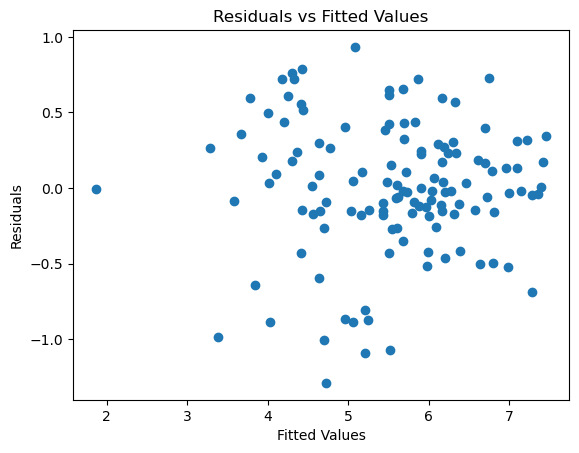

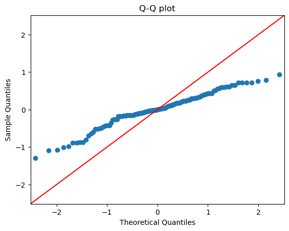

```
Durbin-Watson statistic: 1.898771466659255
```

```python
# Generate model residuals
residuals = model.resid

# Residuals vs Fitted plot
plt.scatter(model.fittedvalues, residuals)
plt.xlabel('Fitted Values')
plt.ylabel('Residuals')
plt.title('Residuals vs Fitted Values')
plt.show()

# QQ plot
sm.qqplot(residuals, line='45')
plt.title('Q-Q plot')
plt.show()

# Durbin-Watson test
dw = sm.stats.durbin_watson(residuals)
print(f"Durbin-Watson statistic: {dw}")
```

### Durbin-Watson Statistic

- **Durbin-Watson Statistic: 1.899**
  - The value is close to 2, which suggests that there is no significant autocorrelation in the residuals. This is good as it means the model meets the assumption of independence among residuals.

## Cross-Validation

#### Cross-validation and splitting data into training and testing sets are crucial for assessing the model's performance on unseen data.

```python
def perform_linear_regression(df, feature_cols, target_col, test_size=0.2, random_state=42, cv_folds=5):

    # Separate dataframe into features (X) and target (y)
    X = df[feature_cols]
    y = df[target_col]

    # Split data into training and test sets
    X_train, X_test, y_train, y_test = train_test_split(X, y, test_size=test_size, random_state=random_state)

    # Initialize and train the model
    model = LinearRegression()
    model.fit(X_train, y_train)

    # Score the model on the test data
    test_score = model.score(X_test, y_test)
    print(f"Test Score: {test_score}")

    # Perform k-Fold Cross Validation
    cv_scores = cross_val_score(model, X, y, cv=cv_folds)
    print(f"Cross-validation Scores: {cv_scores}")
    print(f"Average Cross-validation Score: {cv_scores.mean()}")

    return test_score, cv_scores

feature_columns = ['Logged GDP per capita', 'Social support', 'Healthy life expectancy',
                   'Freedom to make life choices', 'Perceptions of corruption']
target_column = 'Ladder score'

perform_linear_regression(merged_df3, feature_columns, target_column)
```

```
Test Score: 0.834097134325523
Cross-validation Scores: [-1.29827708 -5.36371566 -0.85091884 -5.08457884 -1.32302534]
Average Cross-validation Score: -2.7841031512152603
```

```
(0.834097134325523,
 array([-1.29827708, -5.36371566, -0.85091884, -5.08457884, -1.32302534]))
```

```python
def train_and_evaluate_model(df, feature_columns, target_column, test_size=0.2, random_state=42, cv_folds=5):

    # Separate DataFrame into features (X) and target (y)
    X = df[feature_columns]
    y = df[target_column]

    # Split data
    X_train, X_test, y_train, y_test = train_test_split(X, y, test_size=test_size, random_state=random_state)

    # Initialize model
    model = LinearRegression()

    # Fit model on training data
    model.fit(X_train, y_train)

    # Score model on test data
    test_score = model.score(X_test, y_test)
    print(f"Test Score: {test_score}")

    # k-Fold Cross Validation
    cv_scores = cross_val_score(model, X, y, cv=cv_folds)
    print(f"Cross-validation Scores: {cv_scores}")
    avg_cv_score = cv_scores.mean()
    print(f"Average Cross-validation Score: {avg_cv_score}")

    return test_score, cv_scores, avg_cv_score

# Usage
feature_columns = ['Logged GDP per capita', 'Social support', 'Healthy life expectancy',
                   'Freedom to make life choices', 'Perceptions of corruption']
target_column = 'Ladder score'
test_score, cv_scores, avg_cv_score = train_and_evaluate_model(merged_df3, feature_columns, target_column)
```

```
Test Score: 0.834097134325523
Cross-validation Scores: [-1.29827708 -5.36371566 -0.85091884 -5.08457884 -1.32302534]
Average Cross-validation Score: -2.7841031512152603
```

### Test Score

- **Test Score: 0.834**
  - This is the R-squared value on the test set. It's quite high, meaning that approximately 83.4% of the variability in the dependent variable can be explained by the model. This suggests that the model has a good fit.

### Cross-Validation Scores

- **Cross-validation Scores: [-1.298, -5.363, -0.8509, -5.084, -1.323]**
- **Average Cross-validation Score: -2.784**
  - These scores are negative, and the average is significantly negative as well. In the context of cross-validation, a negative R-squared value usually implies that the model is performing worse than a horizontal line (no predictive power). These values raise concerns about the model's ability to generalize to unseen data and suggest that the model may be overfitting the training data.

## Conclusion and Future Recommendations

### Summary of Findings in the Context of the Summary Question

- Our research focused on understanding how socio-economic and demographic factors affect a country's happiness ranking.
- The regression model accounts for approximately 83.4% of the variability in the "Ladder Score," which is used as a measure of a country's happiness.
- Significant predictors of happiness include "Logged GDP per capita," "Social Support," and "Freedom to make life choices."

#### Addressing the Summary Question

- The findings provide clear evidence that socio-economic factors like GDP per capita and social support are integral in influencing a country's happiness rank.
- Individual freedom to make life choices significantly contributes to happiness, shedding light on the social and political dimensions of well-being.

### Implications for Policy-Makers and Leaders

- **Economic Development**: Given the significance of GDP per capita, economic development should be a priority.
- **Social Well-Being**: The importance of social support systems cannot be overstated. Strong social welfare programs are essential.
- **Individual Freedom**: Freedom to make life choices is a crucial element in happiness, underlining the role of democratic governance and individual liberties.

### Areas for Future Research

1. **Investigate Overfitting**: The model may be overfitting the data, warranting the exploration of regularization techniques.
2. **Feature Engineering**: Introduction of additional variables like education, crime, and other social metrics could enhance the model.
3. **Different Model Architectures**: Other types of models like Tree-based or Neural Networks could provide better generalizability.
4. **Longitudinal Analysis**: Analyzing these factors over time could yield further insights into their causal relationships with happiness.